# 1 Differential expression

## 1.1 Differential expression using limma-voom and SVA

Differential expression analysis consists of identifying changes in gene expression. For RNAseq experiments, this means comparing relative concentrations of RNA molecules. In R, this can be done by using the [limma](http://bioconductor.org/packages/release/bioc/html/limma.html) and [sva](http://bioconductor.org/packages/sva.html) R/Bioconductor packages.

#### 1.1.0.1 Analysis

`limma` allows for linear model analysis of data for DE. This requires building two model matrices: a matrix of the model including the outcome of interest and adjustment variables, and a matrix of the null model that only includes adjustment variables. The outcome of interest is the type of sample (tumor vs normal), and as both types of samples come from the same patient the analysis is paired, so a unique identifier for each patient is included. Finally, as there are unknown factors to adjust, an intercept term of 1 is given to the null model.

Even if no known sources of variation were found, surrogate variables representing unknown sources of variation can be added to the model. Those can be estimated with the `sva` package, and later be appended to the model. Finally, `voom` is used to fit the model as the library size distribution is not uniform across samples, and the moderated t-statistics are calculated.

```r
library(sva)
# Obtain the patient ID, as the analysis is paired
patientid <- substr(colnames(se.filt), 9, 12)
samplevial <- substr(colnames(se.filt), 14, 16)

# Build the model (mod) and null (mod0) matrices
mod <- model.matrix(~type + patientid, data = colData(se.filt))
mod0 <- model.matrix(~1, data = colData(se.filt))

# Estimate surrogate variables
sv <- sva(assays(se.filt)$logCPM, mod = mod, mod0 = mod0)
```

```
Number of significant surrogate variables is:  12
Iteration (out of 5 ):1  2  3  4  5
```

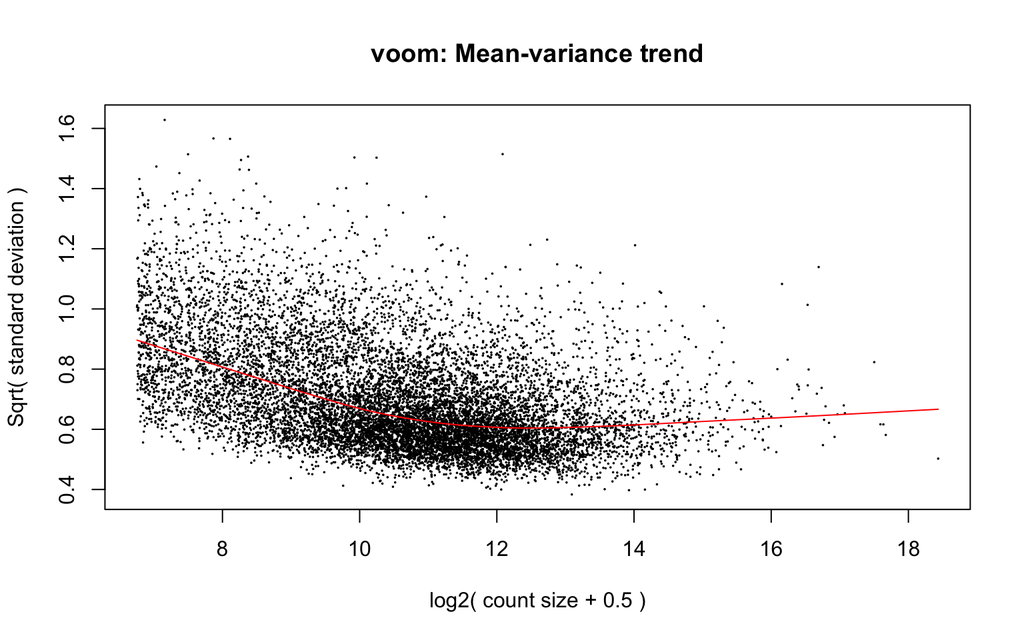

Figure 1: Mean-variance plot for DE analysis with SVA

```r
#pv <- f.pvalue(assays(se.filt)$logCPM, mod, mod0)
#sum(p.adjust(pv, method="fdr") < 0.01)

# Add surrogates to the design matrix
len <- length(colnames(mod))
mod <- cbind(mod, sv$sv)
colnames(mod) <- c(colnames(mod)[1:len], paste0("SV", 1:sv$n))
v <- voom(dge.filt, mod, plot=TRUE)
```

```r
fit <- lmFit(v, mod) # Fit the model with the voom weights
fit <- eBayes(fit) # Calculate moderated t-statistics
```

`sva` was able to estimate 12 surrogate variables. Regarding the mean-variance plot shown in Figure 1, which was obtained with `voom`, it shows the variance in the y axis and the mean of expression in the x axis for each gene, represented as a black dot. Such plots contain a red curve that is fitted to the dots and show trends in the data. Normally increases in expression levels mean a decrease in the variance, until a plateau is reached for highly expressed genes. This trend is observed in the plot obtained for this data. Moreover, the plot is also a diagnosis of filtering steps performed upstream. The fact that there is not a drop in variance for the lower expression values indicates that the filtering threshold was good.

As we are performing multiple tests, the probability of type I errors (rejecting the null hypotheses when it is true) increases. There are multiple statistical strategies to decrease the likelihood of these errors, such as the false discovery rate (FDR). This technique consists of defining an acceptable rate of type I errors (false discoveries). Here, a FDR of 0.1 is set, which means that 10% of the rejections of the null hypothesis will be incorrect. For example, if the data set has 11872 observations, up to 1187 genes can be false positives (FP).

```r
FDRcutoff <- 0.1
res <- decideTests(fit, p.value = FDRcutoff)
summary(res)
```

```
       (Intercept) typetumor patientid3394 patientid4079 patientid4080
Down             2         0             0            10             4
NotSig         503     11872         11870         11858         11864
Up           11367         0             2             4             4
       patientid4081 patientid4587 patientid4593 patientid4609 patientid5040
Down               3             5             1             0             1
NotSig         11868         11866         11869         11871         11869
Up                 1             1             2             1             2
       patientid5471 patientid5472 patientid5478 patientid5481 patientid5482
Down               3             4             0             5             2
NotSig         11867         11866         11870         11866         11869
Up                 2             2             2             1             1
       patientid5483 patientid5489 patientid5491 patientid5670 patientid6143
Down               4             4             0             1             1
NotSig         11866         11864         11870         11869         11869
Up                 2             4             2             2             2
       patientid6647 patientid6737 patientid6771 patientid6773 patientid6837
Down               4             4             1             2             0
NotSig         11865         11863         11869         11868         11871
Up                 3             5             2             2             1
       patientid7107 patientid7138 patientid7142 patientid7222 patientid7335
Down               1             2             5             0             6
NotSig         11870         11870         11864         11869         11863
Up                 1             0             3             3             3
       patientid7337 patientid7338 patientid7340 patientid7579 patientid7580
Down               0             3             9             2             5
NotSig         11870         11867         11856         11868         11863
Up                 2             2             7             2             4
       patientid7582 patientid7657 patientid7658 patientid7710 patientid7730
Down               3             6             6            16             2
NotSig         11862         11863         11865         11852         11868
Up                 7             3             1             4             2
       patientid7731 patientid7767 patientid7823 patientid8007 patientid8008
Down               5             2             9             5            10
NotSig         11864         11866         11857         11865         11859
Up                 3             4             6             2             3
       patientid8082 patientid8083 patientid8201 patientid8309 patientid8386
Down               6             0             1             0             0
NotSig         11865         11870         11870         11872         11870
Up                 1             2             1             0             2
       patientid8454 patientid8623   SV1   SV2   SV3   SV4   SV5   SV6   SV7
Down              10             1  1627  2358  2434  1780  2269   609   840
NotSig         11860         11871  8057  7653  7096  8796  7539 10297 10344
Up                 2             0  2188  1861  2342  1296  2064   966   688
         SV8   SV9  SV10  SV11  SV12
Down     506  1209   584   261   777
NotSig 10708  9410 10940 11474 10658
Up       658  1253   348   137   437
```

The summary table displays the upregulated, not significant, and downregulated genes for each variable in the model.

Gene metadata such as the gene symbol and the chromosome can be added for an easier interpretation of the obtained statistics, and to observe the chromosome distribution of the differentially expressed genes.

```r
# Get gene info...
genesmd <- data.frame(chr = as.character(seqnames(rowRanges(se.filt))), symbol = rowData(se.filt)[, 1], stringsAsFactors = FALSE)

# and add it to the results
fit$genes <- genesmd
tt <- topTable(fit, coef = 2, n = Inf)
head(tt, n = 20)
```

```
            chr    symbol      logFC  AveExpr         t      P.Value
3737       chr1     KCNA2  1.6523859 7.026452  3.255175 0.0022221622
54465      chr2     ETAA1  1.0137545 6.562986  2.707812 0.0097034213
6670       chr2       SP3 -2.2490625 6.764293 -2.615218 0.0122754594
339967     chr4 TMPRSS11A  3.8335792 6.734761  2.746793 0.0087774558
23409     chr12     SIRT4 -0.7817644 5.466508 -2.569058 0.0137789764
5782       chr7    PTPN12  1.3868944 8.717041  2.489535 0.0167688811
79758     chr13    DHRS12  0.7987002 5.558342  2.513815 0.0157987162
2219       chr9      FCN1  1.7434978 5.212160  2.842795 0.0068343407
100422861 chr13   MIR4306 -0.8797975 5.264942 -2.621313 0.0120885818
7334      chr12     UBE2N -4.0884005 2.144869 -4.230825 0.0001208996
10016      chr5     PDCD6 -0.8539103 8.838938 -2.470907 0.0175496214
1833      chr12      EPYC  1.2032674 6.339338  2.400190 0.0208225585
51720      chr5     UIMC1 -1.9410828 5.495497 -2.477388 0.0172743027
23786     chr22   BCL2L13  1.1068231 5.524786  2.544000 0.0146639361
```

[output cut: 27 more lines]

This table contains the relevant statistics used in the analysis, such as raw and adjusted p-values. In the case of the later ones, it can be seen that their values are close to one, which means that the result is not significant. The number of differentially expressed genes under the 0.1 FDR cuttoff can be checked by applying a filter to this table.

```r
DEgenes <- rownames(tt)[tt$adj.P.Val < FDRcutoff]
length(DEgenes)
```

```
[1] 0
```

The differential expression analysis results in 0 differentially expressed genes. As there are not DE genes, the chromosome distribution cannot be done.

#### 1.1.0.2 Diagnostics

The distribution of raw p-values and the QQ plot moderated t-statistics, displayed in Figure 2, can be used as a diagnosis of the tests performed.

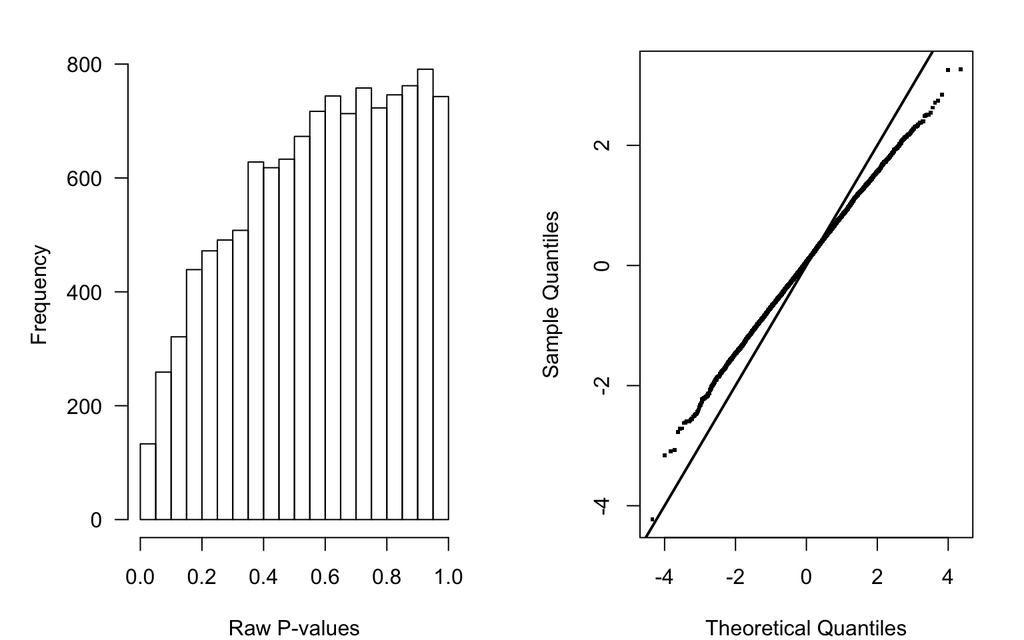

Figure 2: Raw p-values distribution and QQ plot of the moderated t-statistics for DE analysis with SVA

```r
par(mfrow = c(1, 2), mar = c(4, 5, 2, 2))
hist(tt$P.Value, xlab = "Raw P-values", main = "", las = 1)
qqt(fit$t[, 2], df = fit$df.prior + fit$df.residual, main = "", pch = ".", cex = 3)
abline(0, 1, lwd = 2)
```

Under the null hypothesis, which is that most genes are not differentially expressed, the raw p-value distribution should be uniform with a peak at low p-values for the truly DE genes. It is not the case.

Regarding the QQ plot, it represents the quantiles of our data sample against the theoretical distribution they should follow. The diagonal represents the null hypothesis. Most genes are off-diagonal, indicating that differentially expressed genes exist, but they are still close to the diagonal because they are not significant.

## 1.2 Alternative differential expression analysis approaches

As said previously, adding surrogate variables adjusts for unknown variation, which in practice would translate into an increased number of differentially expressed genes with respect to analyses performed without including them. Usually this unknown variation would account for non-biological variability, but in some cases the surrogate variables can capture biological variability that is important for the outcome. One of such cases happens when there is some sort of heterogeneity in the data, such as unknown subgroups. When this happens, `sva` is not reccomended.

Following this idea, two different modifications to the surrogate variables before performing the diferential expression analysis were done. In the first case they were not included, while only one of them was removed in the second. Note that code that was identical to the first analysis will not be displayed for clarity.

### 1.2.1 Differential expression analysis without surrogate variable adjustment

The first analysis will consist on the removal of the surrogate variable estimation and inclusion into the model.

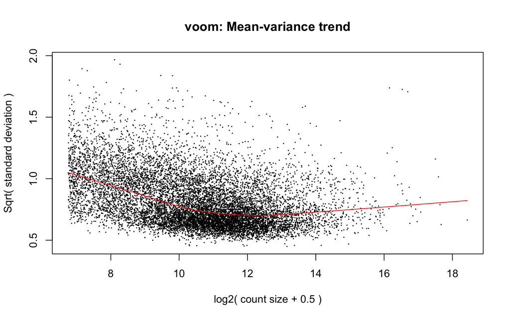

Figure 3: Mean-variance plot for DE analysis without SVA

```r
# Obtain the patient ID, as the analysis is paired
patientid <- substr(colnames(se.filt), 9, 12)
samplevial <- substr(colnames(se.filt), 14, 16)

# Build the model (mod) and null (mod0) matrices
mod <- model.matrix(~type + patientid, data = colData(se.filt))
mod0 <- model.matrix(~1, data = colData(se.filt))

v <- voom(dge.filt, mod, plot=TRUE)
```

```r
fit <- lmFit(v, mod) # Fit the model with the voom weights
fit <- eBayes(fit) # Calculate moderated t-statistics
```

```
       (Intercept) typetumor patientid3394 patientid4079 patientid4080
Down             3      4001             0             1             0
NotSig         938      3261         11870         11869         11871
Up           10931      4610             2             2             1
       patientid4081 patientid4587 patientid4593 patientid4609 patientid5040
Down               0             4             1             0             0
NotSig         11871         11866         11870         11871         11871
Up                 1             2             1             1             1
       patientid5471 patientid5472 patientid5478 patientid5481 patientid5482
Down               0             0             0             4             1
NotSig         11871         11870         11871         11867         11870
Up                 1             2             1             1             1
       patientid5483 patientid5489 patientid5491 patientid5670 patientid6143
Down               0             0             0             0             1
NotSig         11871         11870         11870         11871         11869
Up                 1             2             2             1             2
       patientid6647 patientid6737 patientid6771 patientid6773 patientid6837
Down               4             0             0             1             0
NotSig         11867         11870         11870         11870         11871
Up                 1             2             2             1             1
       patientid7107 patientid7138 patientid7142 patientid7222 patientid7335
Down               0             2             6             0             8
NotSig         11871         11870         11866         11871         11862
Up                 1             0             0             1             2
       patientid7337 patientid7338 patientid7340 patientid7579 patientid7580
Down               1             1             5             0             2
NotSig         11869         11870         11864         11871         11869
Up                 2             1             3             1             1
       patientid7582 patientid7657 patientid7658 patientid7710 patientid7730
Down               1             4             4             8             0
NotSig         11870         11866         11868         11863         11871
Up                 1             2             0             1             1
       patientid7731 patientid7767 patientid7823 patientid8007 patientid8008
Down               4             0             5             2             1
NotSig         11866         11870         11866         11869         11870
Up                 2             2             1             1             1
       patientid8082 patientid8083 patientid8201 patientid8309 patientid8386
Down               5             0             0             0             0
NotSig         11866         11870         11871         11872         11871
Up                 1             2             1             0             1
       patientid8454 patientid8623
Down               5             0
NotSig         11866         11872
Up                 1             0
```

```
            chr   symbol     logFC  AveExpr         t      P.Value
171482     chrX    FAM9A  6.684090 1.398244  29.87458 2.675630e-35
692205     chr2  SNORD89  4.479288 4.052144  28.34534 3.881159e-34
9263       chr7   STK17A  5.404630 7.068959  27.99553 7.284182e-34
121391    chr12    KRT74  3.721899 3.731252  27.91609 8.411891e-34
6100       chr7      RP9  3.689315 4.777322  27.71353 1.216153e-33
94134     chr10 ARHGAP12  3.151818 3.756260  27.16175 3.359784e-33
27316      chrX     RBMX  4.154444 3.580128  26.74821 7.280866e-33
93129     chr16    ORAI3  4.173886 3.175301  26.37794 1.468031e-32
81556     chr15     VWA9  4.381863 2.033731  26.24892 1.878105e-32
2079      chr14      ERH  3.999127 1.261490  26.09320 2.531932e-32
2261       chr4    FGFR3  4.369444 4.414508  25.97522 3.178191e-32
55143      chr1    CDCA8  4.108178 3.754213  25.96393 3.248239e-32
10523     chr19    CHERP  2.996771 3.530494  25.88867 3.757083e-32
6406      chr20    SEMG1  2.404315 4.902333  25.16958 1.537283e-31
```

[output cut: 27 more lines]

A drop on the adjusted p-values is already observed, leading to significant expression changes. The number of significantly differentially expressed genes is obtained by filtering the table by the 0.01 FDR cuttoff value.

```
[1] 8611
```

In this case, the differential expression analysis results in 8611 significant differentially expressed genes, even with a really strict FDR cutoff. In this case, the chromosome distribution of the genes can be assessed.

```r
sort(table(tt$chr[tt$adj.P.Val < FDRcutoff]), decreasing = TRUE)
```

```
                chr1                chr19                 chr2
                 875                  630                  584
               chr11                 chr3                chr17
                 573                  505                  482
               chr12                 chr7                 chr6
                 478                  404                  383
                chr5                 chr9                chr16
                 367                  360                  347
                chr4                 chrX                chr10
                 327                  324                  311
               chr14                chr15                 chr8
                 294                  263                  257
               chr20                chr22                chr13
                 247                  199                  166
               chr18                chr21                 chrY
                 110                  108                   11
 chr1_KI270766v1_alt chr11_JH159137v1_alt chr19_GL949747v2_alt
                   1                    1                    1
chr19_KI270921v1_alt chr22_KI270879v1_alt     chrUn_GL000218v1
                   1                    1                    1
```

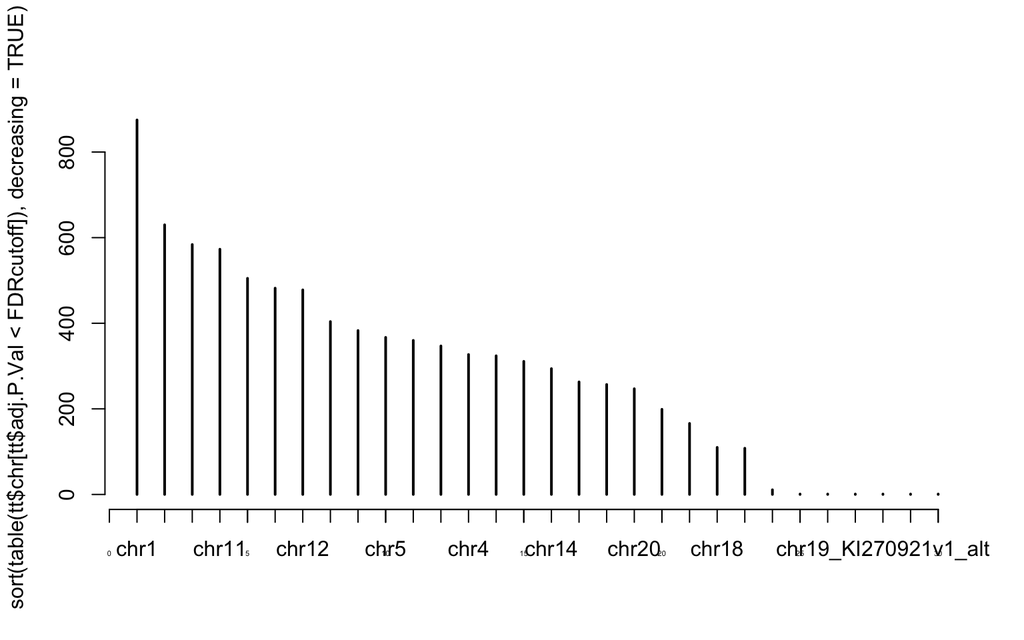

Figure 4: Chromosome distribution of the DE genes for the analysis without SVA

```r
plot(sort(table(tt$chr[tt$adj.P.Val < FDRcutoff]), decreasing = TRUE))
axis(side=1, cex.axis=0.35)
```

The distribution is shown in Figure 4, and it is pretty variable: some differentially expressed genes are located in big chromosomes, but smaller chromosomes are sometimes located higher in the ranking from what would be expected by its size.

A list of the top 10 differentially expressed genes can be obtained:

```r
top <- order(fit$lods[, 2], decreasing = TRUE)[1:10]
fit$genes$symbol[top]
```

```
 [1] "FAM9A"    "SNORD89"  "STK17A"   "KRT74"    "RP9"      "ARHGAP12"
 [7] "RBMX"     "ORAI3"    "VWA9"     "ERH"
```

#### 1.2.1.1 Diagnostics

The performance of the statistical test is assessed in the 5 with the distribution of raw p-values and the QQ plot moderated t-statistics.

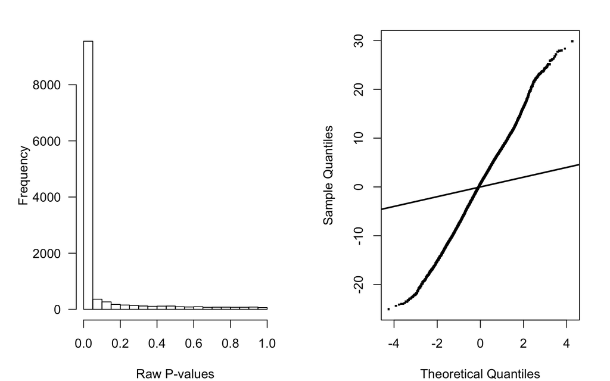

Figure 5: Raw p-values distribution and QQ plot of the moderated t-statistics for DE analysis without SVA

The assumption of a flat distribution of raw p-values for the non-DE genes under the null hypothesis holds in this case. In the QQ plot, more genes are far from the null hypothesis, which indicates significant differential expression.

The results are diagnosed with volcano and MA plots, in which the top 10 differentially expressed genes are highlighted as shown in Figure 6.

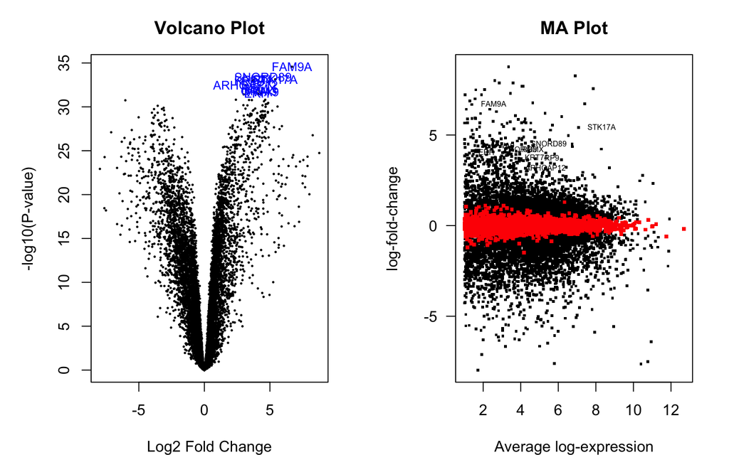

Figure 6: Volcano and MA plots for DE analysis without SVA

```r
par(mfrow = c(1, 2), mar = c(4, 5, 3, 2))
volcanoplot(fit, coef = 2, highlight = 10, names = fit$genes$symbol, main = "Volcano Plot")

limma::plotMA(fit, coef = 2, status = rownames(fit$lods) %in% DEgenes, legend = FALSE,
main = "MA Plot", hl.pch = 46, hl.cex = 4, bg.pch = 46, bg.cex = 3, las = 1)
text(fit$Amean[top], fit$coef[top, 2], fit$genes$symbol[top], cex = 0.5, pos = 4)
```

### 1.2.2 Differential expression analysis removing the first surrogate variable

The removal of all the surrogate variables might be considered radical, as some of them might be capturing part of the unwanted non-biological variation. It is possible that only one of the variables is capturing the relevant biological information. By removing each of them one at a time, it was observed that the variable responsible for this was the first one, so the following analysis is performed by removing it. The others can be done by simply modifying the number on the `svmod <- sv$sv[,-1]` line.

#### 1.2.2.1 Analysis

```r
library(sva)
# Obtain the patient ID, as the analysis is paired
patientid <- substr(colnames(se.filt), 9, 12)
samplevial <- substr(colnames(se.filt), 14, 16)

# Build the model (mod) and null (mod0) matrices
mod <- model.matrix(~type + patientid, data = colData(se.filt))
mod0 <- model.matrix(~1, data = colData(se.filt))

# Estimate surrogate variables
sv <- sva(assays(se.filt)$logCPM, mod = mod, mod0 = mod0)
```

```
Number of significant surrogate variables is:  12
Iteration (out of 5 ):1  2  3  4  5
```

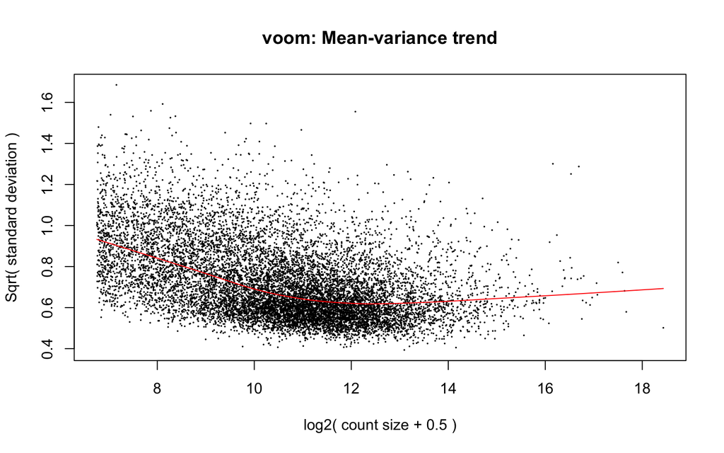

Figure 7: Mean-variance plot for DE analysis without SV1

```r
# Remove the first surrogate variable
svmod <- sv$sv[,-1]

# Add surrogates to the design matrix
len <- length(colnames(mod))
mod <- cbind(mod, svmod)
colnames(mod) <- c(colnames(mod)[1:len], paste0("SV", 1:(sv$n-1)))
v <- voom(dge.filt, mod, plot=TRUE)
```

```r
fit <- lmFit(v, mod) # Fit the model with the voom weights
fit <- eBayes(fit) # Calculate moderated t-statistics
```

`sva` estimated 12 surrogate variables, though 11 will be used. There are not relevant variations in the mean-variance plot (Figure 7)

The correction for multiple testing is maintained to a FDR of 0.01. Some preliminary data on upregulation and downregulation is obtained and gene metadata is added for interpretation purposes.

```
       (Intercept) typetumor patientid3394 patientid4079 patientid4080
Down             4      4427             0             5             0
NotSig         795      2555         11870         11864         11871
Up           11073      4890             2             3             1
       patientid4081 patientid4587 patientid4593 patientid4609 patientid5040
Down               3             4             1             0             0
NotSig         11868         11867         11870         11871         11871
Up                 1             1             1             1             1
       patientid5471 patientid5472 patientid5478 patientid5481 patientid5482
Down               0             0             0             4             2
NotSig         11871         11870         11871         11867         11869
Up                 1             2             1             1             1
       patientid5483 patientid5489 patientid5491 patientid5670 patientid6143
Down               0             1             0             0             1
NotSig         11871         11869         11870         11871         11869
Up                 1             2             2             1             2
       patientid6647 patientid6737 patientid6771 patientid6773 patientid6837
Down               4             0             0             1             0
NotSig         11867         11870         11870         11870         11871
Up                 1             2             2             1             1
       patientid7107 patientid7138 patientid7142 patientid7222 patientid7335
Down               0             1             3             0             4
NotSig         11871         11871         11869         11871         11866
Up                 1             0             0             1             2
       patientid7337 patientid7338 patientid7340 patientid7579 patientid7580
Down               0             0             3             0             1
NotSig         11870         11871         11867         11871         11870
Up                 2             1             2             1             1
       patientid7582 patientid7657 patientid7658 patientid7710 patientid7730
Down               0             4             5             8             1
NotSig         11871         11866         11867         11862         11870
Up                 1             2             0             2             1
       patientid7731 patientid7767 patientid7823 patientid8007 patientid8008
Down               5             0             6             2             8
NotSig         11865         11870         11865         11869         11863
Up                 2             2             1             1             1
       patientid8082 patientid8083 patientid8201 patientid8309 patientid8386
Down               4             0             0             0             0
NotSig         11867         11870         11871         11872         11871
Up                 1             2             1             0             1
       patientid8454 patientid8623   SV1   SV2   SV3   SV4   SV5   SV6   SV7
Down               5             2  1451  1032   595  1081    67    54    71
NotSig         11866         11870  9629  9716 10924 10055 11600 11774 11735
Up                 1             0   792  1124   353   736   205    44    66
         SV8   SV9  SV10  SV11
Down     251    74    27   199
NotSig 11372 11778 11842 11635
Up       249    20     3    38
```

```
            chr   symbol     logFC   AveExpr         t      P.Value
171482     chrX    FAM9A  6.645572  1.398244  33.87783 7.509160e-33
158062     chr9     LCN6  7.932107  6.903857  32.23290 6.005917e-32
2261       chr4    FGFR3  4.302083  4.414508  31.24488 2.195920e-31
23217     chr19     ZFR2  4.886302  6.536403  31.18890 2.365935e-31
51569     chr13     UFM1  5.514912  2.997682  30.45650 6.349201e-31
117156     chr5  SCGB3A2  4.312446  6.753572  30.17659 9.312345e-31
9263       chr7   STK17A  5.352539  7.068959  29.99144 1.201872e-30
3934       chr9     LCN2  7.236816  7.858414  29.99365 1.198209e-30
2899       chr1    GRIK3 -4.135019  7.203114 -28.90887 5.500876e-30
100616453 chr11  MIR4687  3.395674  5.795113  28.53458 9.419651e-30
29886      chr7     SNX8  7.253835  3.450086  27.80469 2.739171e-29
85365      chr9     ALG2  3.732885  1.154094  27.86468 2.506738e-29
692205     chr2  SNORD89  4.455857  4.052144  27.65038 3.443693e-29
94134     chr10 ARHGAP12  3.151209  3.756260  27.54928 4.003349e-29
```

[output cut: 27 more lines]

As in the study without surrogate variables, a drop on the adjusted p-values is already observed, leading to significant expression changes. The number of significantly differentially expressed genes is obtained by filtering the table by the 0.01 FDR cuttoff value.

```
[1] 9317
```

So the differential expression analysis without the first surrogate variable results in 9317 differentially expressed genes. Their chromosome distribution can be assessed.

```
                chr1                chr19                 chr2
                 953                  680                  630
               chr11                 chr3                chr17
                 609                  541                  530
               chr12                 chr7                 chr6
                 510                  433                  430
                chr5                 chr9                chr16
                 401                  396                  371
                chr4                 chrX                chr10
                 357                  351                  329
               chr14                chr15                 chr8
                 320                  287                  277
               chr20                chr22                chr13
                 265                  214                  178
               chr18                chr21                 chrY
                 118                  118                   12
 chr1_KI270765v1_alt  chr1_KI270766v1_alt chr11_JH159137v1_alt
                   1                    1                    1
chr19_GL949747v2_alt chr19_KI270921v1_alt chr22_KI270879v1_alt
                   1                    1                    1
    chrUn_GL000218v1
                   1
```

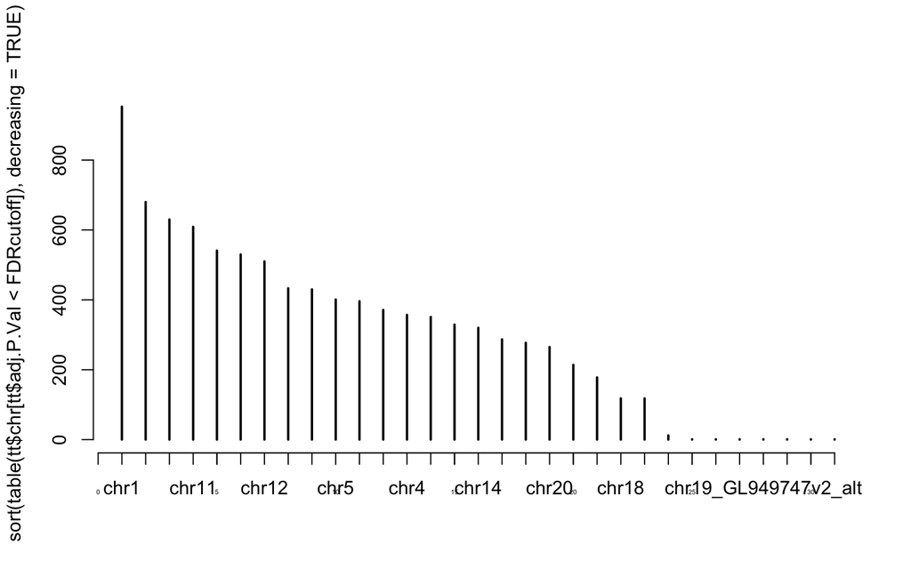

Figure 8: Chromosome distribution of the DE genes for the analysis without SV1

This result also ressembles the analysis without surrogate variables, with a variable distribution in which big chromosomes rank higher, as well as some smaller chromosomes. This can be seen in Figure 8

A list of the top 10 differentially expressed genes can be obtained:

```r
top <- order(fit$lods[, 2], decreasing = TRUE)[1:10]
fit$genes$symbol[top]
```

```
 [1] "FAM9A"   "LCN6"    "FGFR3"   "ZFR2"    "UFM1"    "SCGB3A2" "STK17A"
 [8] "LCN2"    "GRIK3"   "MIR4687"
```

It can be observed that the genes in the list have changed. We will further analyse this in the functional enrichment section.

#### 1.2.2.2 Diagnostics

The performance of the statistical test is diagnosed with the distributions of raw p-values and moderated t-statistics, as shown in Figure 9.

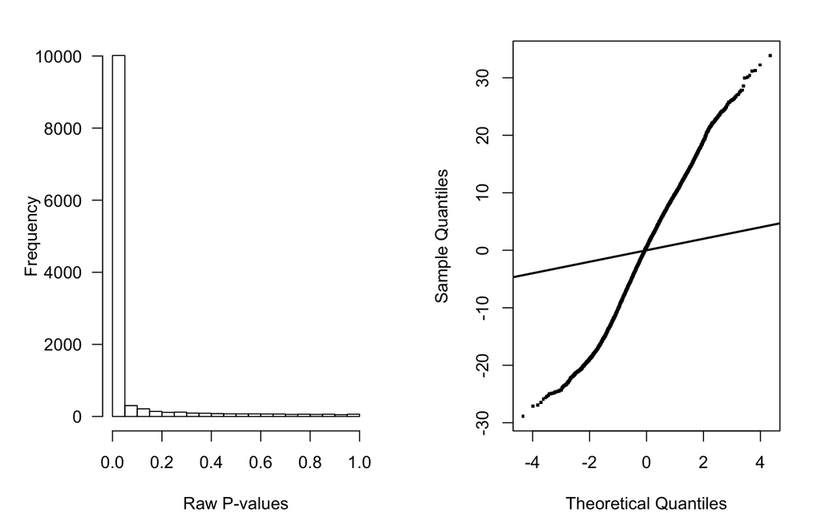

Figure 9: Raw p-values distribution and QQ plot of the moderated t-statistics for DE analysis without SV1

The result is, again, similar to the previous analysis. The flat distribution for non-DE genes is present, but the peak is higher, as there are more differentially expressed genes. The QQ plot is similar to the in the analysis without SVA.

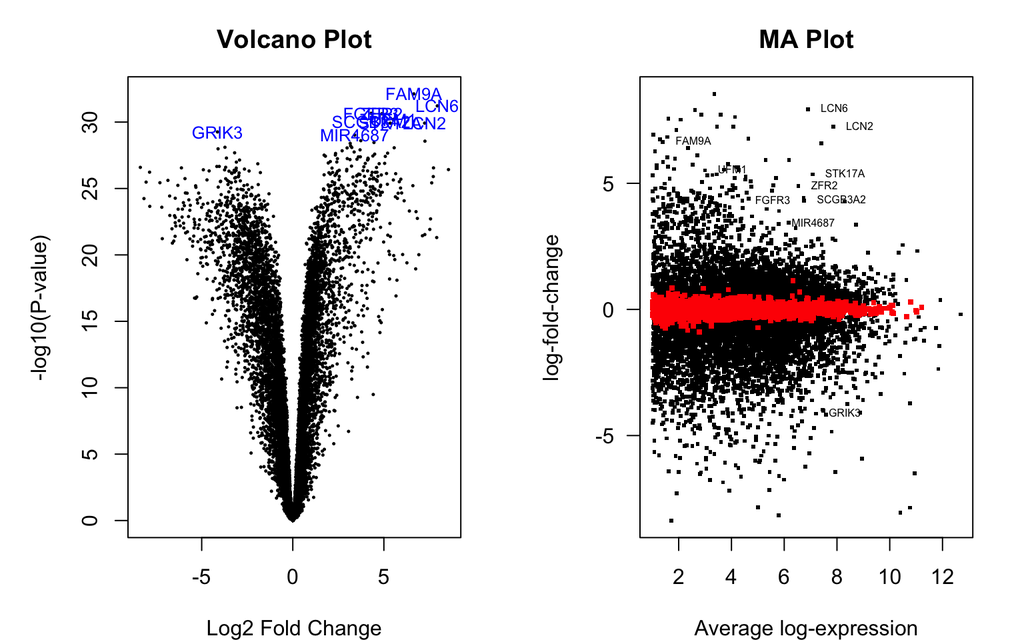

Figure 10: Volcano and MA plots for DE analysis without SV1

### 1.2.3 Performance comparison